# Assignment 2

Pau Villén Vidal (pau.villenvidal01@estudiant.upf.edu)

Last update: 06 March, 2026

In this practical, we will continue working with the proteomic dataset from the publication [**Proteomic and Metabolomic Characterization of COVID-19 Patient Sera**](https://www.sciencedirect.com/science/article/pii/S0092867420306279).

Begin by loading:

- The proteomic data
- The patient metadata (severity, gender, age), as used in the previous exercise

> We begin by loading all the necessary libraries:

```r
library(readxl)
library(dplyr)
library(ggplot2)
library(tibble)
library(cluster)
library(factoextra)
library(ggpubr)
library(dendextend)
library(Rtsne)
library(umap)
library(RColorBrewer)
library(ComplexHeatmap)
library(circlize)
```

# Exercise 1: Clustering

The goal of this exercise is to investigate whether patients naturally cluster based on their serum proteomic profiles and to assess whether these clusters are associated with disease severity, even though severity information is not used during clustering.

> In this first exercise, we perform both K-means and Hierarchical clustering on the proteomic data.

> The codes below correspond first to downloading, cleaning, and preparing the data from both the proteomic data and the patient metadata, and then performing the clustering and matching the patients in the results with their corresponding severity clinical group.

> At the beggining, the code contains one line which removes some patients identified as outliers. These outliers were identified by doing the same procedure with all patients included and detecting some patients appearing very distant from the others in the k-means clusters or as a cluster themselves in the hierarchical clusters.

## K-means clustering

Perform k-means clustering on the proteomic data.

Determine the optimal number of clusters using an appropriate method (e.g. elbow method, silhouette score).

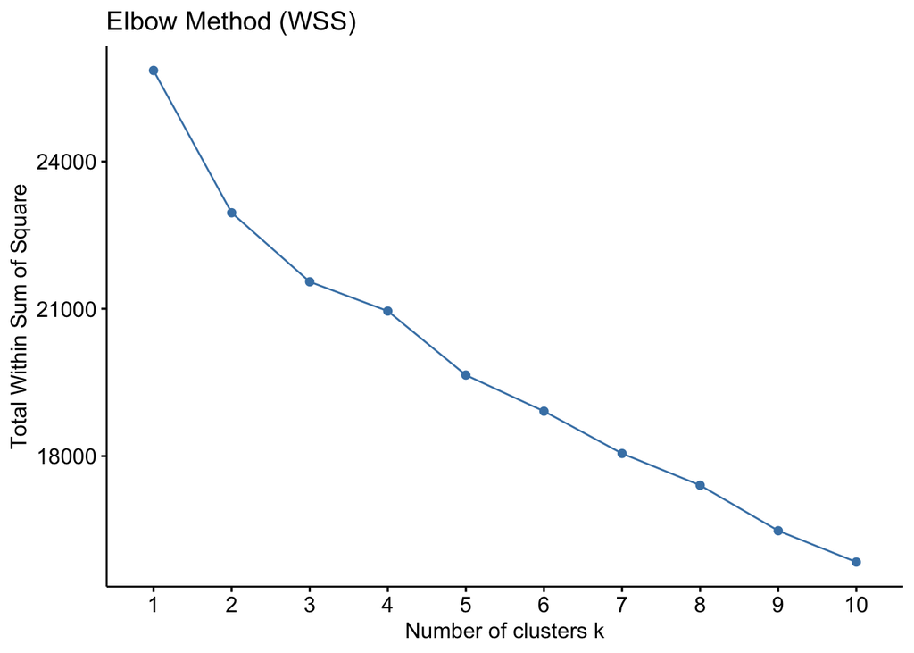

```r
# --- PREPARE DATA (Table s2) ---
# Read table setting correct headers
patient_id_row <- read_excel("table_s2.xlsx", sheet = "Proteomics_proteins_training",
                             skip = 1, n_max = 1, col_names = FALSE)
patient_names <- as.character(unlist(patient_id_row))
df2_raw <- read_excel("table_s2.xlsx", sheet = "Proteomics_proteins_training",
                     skip = 2, col_names = FALSE)
colnames(df2_raw) <- c("Proteins", "Gene_Symbol", patient_names)

# Remove patients identified as outliers
outliers_to_remove <- c("F2_129N", "F2_130N", "F1_130C", "F4_130C", "F1_130N",
                        "F2_130C", "F2_127C")

# Keep all the data frame except the outliers
cols_to_keep <- setdiff(colnames(df2_raw), outliers_to_remove)
df2_raw <- df2_raw[, cols_to_keep]

# Filter missing values (delete proteins with >= 20% missing values)
df2_numeric <- df2_raw %>%
  select(-Gene_Symbol) %>%
  column_to_rownames("Proteins")
df2_numeric <- as.data.frame(lapply(df2_numeric, as.numeric))
rownames(df2_numeric) <- df2_raw$Proteins
missing_rate <- rowMeans(is.na(df2_numeric))
df2_filtered <- df2_numeric[missing_rate < 0.20, ]

# Impute missing values as in the paper: Replace all NA with 0
df2_imputed <- df2_filtered
df2_imputed[is.na(df2_imputed)] <- 0

# Transpose the data frame (we want Patient IDs as rows and Proteins as columns)
df2_transposed <- t(df2_imputed)

# Scale variables before clustering to have mean 0 and sd 1 so that they are comparable
df2_scaled <- scale(df2_transposed)

# --- K-MEANS CLUSTERING ---
# Choosing the optimal number of clusters with Elbow Method
fviz_nbclust(df2_scaled, kmeans, method = "wss") +
  labs(title = "Elbow Method (WSS)")
```

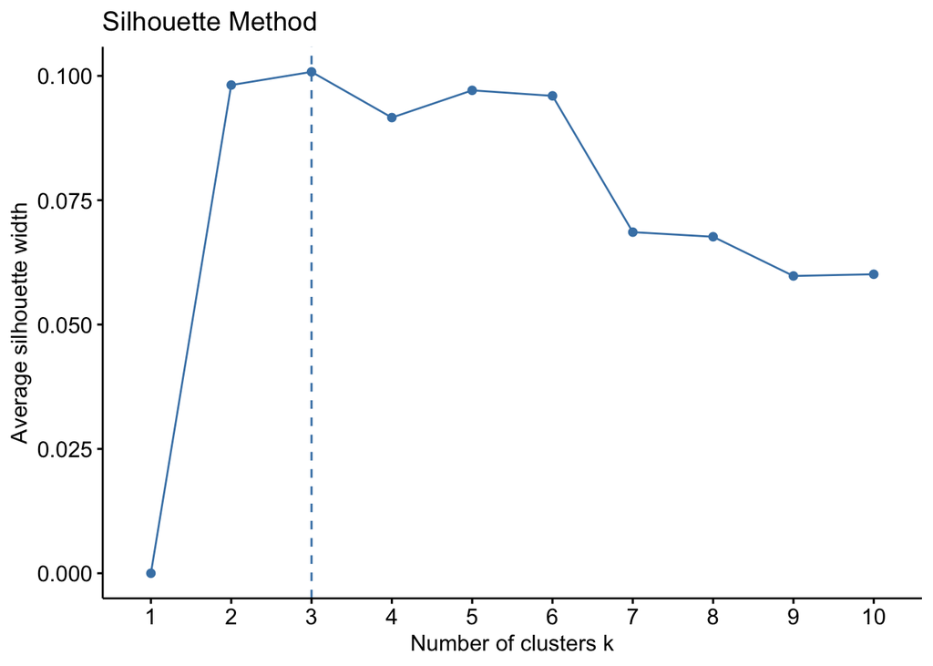

```r
# Choosing the optimal number of clusters with Silhouette Method
fviz_nbclust(df2_scaled, kmeans, method = "silhouette") +
  labs(title = "Silhouette Method")
```